# Reproducible Research: Peer Assessment 1

## Loading and preprocessing the data

As the instructions for this project indicate, this document does not need to include the code related to downloading the data. Instead, I’m going to assume you have this data saved in your working directory.

### Unzip, Load, and Summarize

The data for this project comes in a zip file, but we’ll want to extract that in order to load it into R.

```r
unzip("week2.zip")
```

This will drop activity.csv into your working directory, so next we’ll load the data into R:

```r
activity<-read.csv("activity.csv",colClasses = c("integer","Date","integer"))
```

And we’ll just want to take a peak at what we’ve got to work with

```r
summary(activity)
```

```
##      steps             date               interval
##  Min.   :  0.00   Min.   :2012-10-01   Min.   :   0.0
##  1st Qu.:  0.00   1st Qu.:2012-10-16   1st Qu.: 588.8
##  Median :  0.00   Median :2012-10-31   Median :1177.5
##  Mean   : 37.38   Mean   :2012-10-31   Mean   :1177.5
##  3rd Qu.: 12.00   3rd Qu.:2012-11-15   3rd Qu.:1766.2
##  Max.   :806.00   Max.   :2012-11-30   Max.   :2355.0
##  NA's   :2304
```

And of course, this lets me know that I’ve got a lot of NAs to deal with, but we will get to that later. For now, let’s create another dataset where NA values are all removed:

```r
act_clean<-na.omit(activity)
```

## What is mean total number of steps taken per day?

First we need to aggregate total number of steps per day:

```r
daily<-setNames(
      aggregate(
            act_clean$steps,
            by = list(act_clean$date),
            FUN=sum
            ),
      c("Date","Steps")
      )
```

And then we’ll create a histogram using ggplot2:

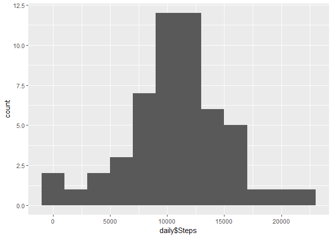

```r
qplot(daily$Steps,geom="histogram",binwidth=2000)
```

I wonder what the mean and median steps are?

```r
mean(daily$Steps)
```

```
## [1] 10766.19
```

```r
median(daily$Steps)
```

```
## [1] 10765
```

I love it when median and mean are that close together.

## What is the average daily activity pattern?

So what does the average daily pattern look like? First, let’s make a new dataset that aggregates the average number of steps per 5 minute interval:

```r
daily_steps<-setNames(aggregate(
            act_clean$steps,
            by = list(act_clean$interval),
            FUN="mean"
            ),
      c("interval","mean_steps"))

head(daily_steps)
```

```
##   interval mean_steps
## 1        0  1.7169811
## 2        5  0.3396226
## 3       10  0.1320755
## 4       15  0.1509434
## 5       20  0.0754717
## 6       25  2.0943396
```

Great. Now let’s plot that!

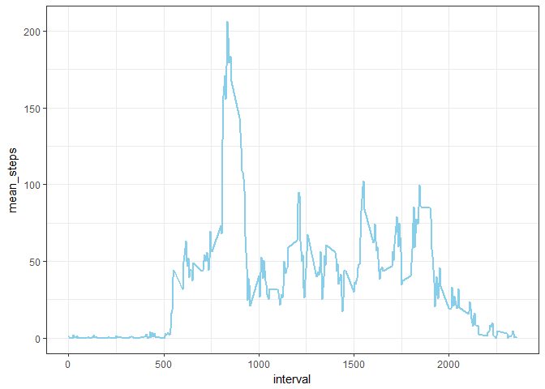

```r
ggplot(daily_steps,aes(interval,mean_steps))+
      geom_line(color = "sky blue",size=1)+
      theme_bw()
```

We can start to see a pretty clear pattern. Looks like the test subject(s) tend to take a morning walk of some kind.

## Imputing missing values

Remeber how earlier we said there were a bunch of NAs in our ‘steps’ data? Well, there are. In fact, there are this many:

```r
sum(is.na(activity$steps))
```

```
## [1] 2304
```

I wonder if ignoring all of those NAs has distorted my data to some degree. So let’s do something about them and see what happens:

```r
act2<-activity
act2$steps[is.na(act2$steps)]<-mean(act2$steps,na.rm = TRUE)
summary(act2$steps)
```

```
##    Min. 1st Qu.  Median    Mean 3rd Qu.    Max.
##    0.00    0.00    0.00   37.38   37.38  806.00
```

Great, with no NAs left in my new ‘act2’ dataset, let’s look at how the data may have changed.

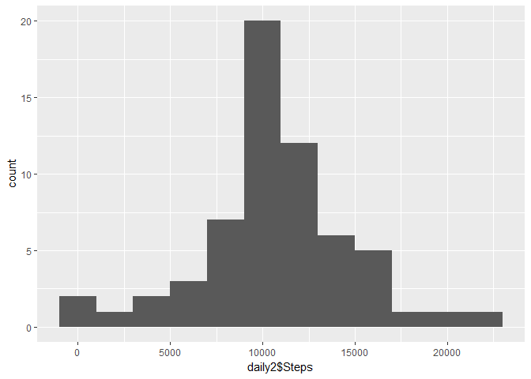

```r
daily2<-setNames(
      aggregate(
            act2$steps,
            by = list(act2$date),
            FUN=sum
            ),
      c("Date","Steps"))

qplot(daily2$Steps,geom="histogram",binwidth=2000)
```

```r
mean(daily2$Steps)
```

```
## [1] 10766.19
```

```r
median(daily2$Steps)
```

```
## [1] 10766.19
```

So, we can see that the shape of the histogram has shifted a bit and that the median value is much more clear. Now, the mean and median are identical, and because of the way that I imputed the NAs, the new median and mean match the original mean of the dataset.

## Are there differences in activity patterns between weekdays and weekends?

We’d like to see if there is a difference in weekdays vs weekends insofar as daily activity goes. So first, we’ll need to create a new variable that identifies if a day falls on a weekday or a weekend.

```r
act2$weekpart<-as.factor(
      ifelse(
            weekdays(act2$date) %in%
                  c("Saturday","Sunday"),
            "Weekend",
            "Weekday"
      )
)
```

Then we can plot activity on weekend days vs weekdays and see what difference may exist.

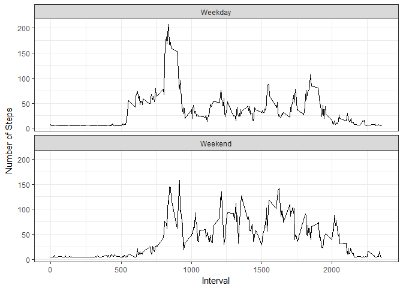

```r
weekpart.daily.steps<-setNames(
      aggregate(
            act2$steps,by=list(act2$interval,act2$weekpart),
            FUN="mean"
      ),
      c("interval","weekpart","meansteps")
)

ggplot(weekpart.daily.steps,aes(interval,meansteps))+
      geom_line()+
      ylab("Number of Steps")+
      xlab("Interval")+
      theme_bw()+
      facet_wrap(~weekpart,nrow=2,ncol=1)
```

There’s definitely less of a spike on the weekends in the early morning (maybe we are missing a walk from the parking lot to the office building?) and more midday steps during the weekend, which may indicate our subject(s) have a more stationary desk job during the week.